# Functional annotation using eggNog

BRC

12/2/2020

# Functional annotation.

To provide additional functional annotation for Ooceraea biroi we will assign annotation from putative orthologs in closely related species. We can avoid the computational burden of exhaustively identifying putative orthologs by using precomputed orthologous groups (collections of othologous genes) at differing taxa levels.

We will use the eggNog database in conjunction with the eggNog-mapper software to identify a full set of GO functional annotations for the Ooceraea biroi genome.

We run this in two modes.

- First following default recommendation by EggNog-mapper
- Second limiting the functional annotation to just within the Insecta taxa level. This will more conservative.

## Following default recommendation by EggNog-mapper

### Version

emapper version: emapper-2.0.1 emapper DB: 2.0

### Command

```bash
./emapper.py  -i obiroi.fa --cpu 30 -m diamond --data_dir dataDirConda/ --output eggnogAnno_CondaVersionPy2
```

### Annotation

The raw eggNog-mapper results can be found in the directory.

**eggNogMapper_Standard/eggNogMapper_Annotations/eggnogAnno_CondaVersionPy2.emapper.annotations**

### Functional annotation graph correction

Following the GO annotation by eggNog-mapper we use topGO software to update assigned annotation accounting for the structured GO graph (i.e. A gene in a GO term must exist in one of the GO terms parent terms).

The update annotation can be found in

**eggNogMapper_Standard/GO_Annotation/GO2Gene_eggnogAnnoFromTopGO_CondaVersionPy2.txt**

### Functional annotation graph enrichment testing

Functional annotation was performed by topGO and results separated in BP (Biological processes), MF (Molecular functions) and CC (cellular components) on the test set of proteins provided **“Proteins in secretion.xlsx”**.

Results tables are in

**eggNogMapper_Standard/topGO_Results/GO2Gene_eggnogAnno_CondaVersionPy2_TopGO_BP.csv**

**eggNogMapper_Standard/topGO_Results/GO2Gene_eggnogAnno_CondaVersionPy2_TopGO_MF.csv**

**eggNogMapper_Standard/topGO_Results/GO2Gene_eggnogAnno_CondaVersionPy2_TopGO_CC.csv**

Results columns are –

- GO.ID - GO ID as provided by GO consortium.
- Term - Description of GO term.
- Annotated - Number of genes annotated to term.
- Significant - Number of genes annotated to term and within the test list of genes.
- Expected - Expected number of genes annotated to term and within the test list of genes.
- Rank in result2 - Rank of p-value if order by Result 2 column.
- result1 - pvalue of enrichment by hypergeometric test (Standard).
- result2 - pvalue of enrichment by hypergeometric test with elim algorithm GO graph correction (Ranks GO terms in bottom of GO graph higher i.e. most specific).
- result3 - pvalue of enrichment by hypergeometric test with weight algorithm GO graph correction (Ranks GO terms in middle of GO graph higher).
- GenesInTermAndTest - The genes annotated to term and within the test list of genes.
- GenesInTermAndTest_eggNogName - Any common names assigned by eggNog to genes annotated to term and within the test list of genes.

In addition we also run the GO enrichment using GOseq which will allow us to expand to other functional sets beyond GO.

Results are in

**eggNogMapper_Standard/GOseq_Results/GO2Gene_eggnogAnno_CondaVersionPy2_GOSEQ.csv**

Results columns are –

- category - GO ID as provided by GO consortium.
- over_represented_pvalue - pvalue of enrichment by fisher test.
- under_represented_pvalue - pvalue of depletion by fisher test.
- numDEInCat - Number of genes annotated to term and within the test list of genes.
- numInCat - Number of genes annotated to term.
- term - Description of GO term.

## GO graph of Biological processes, top 10 enriched

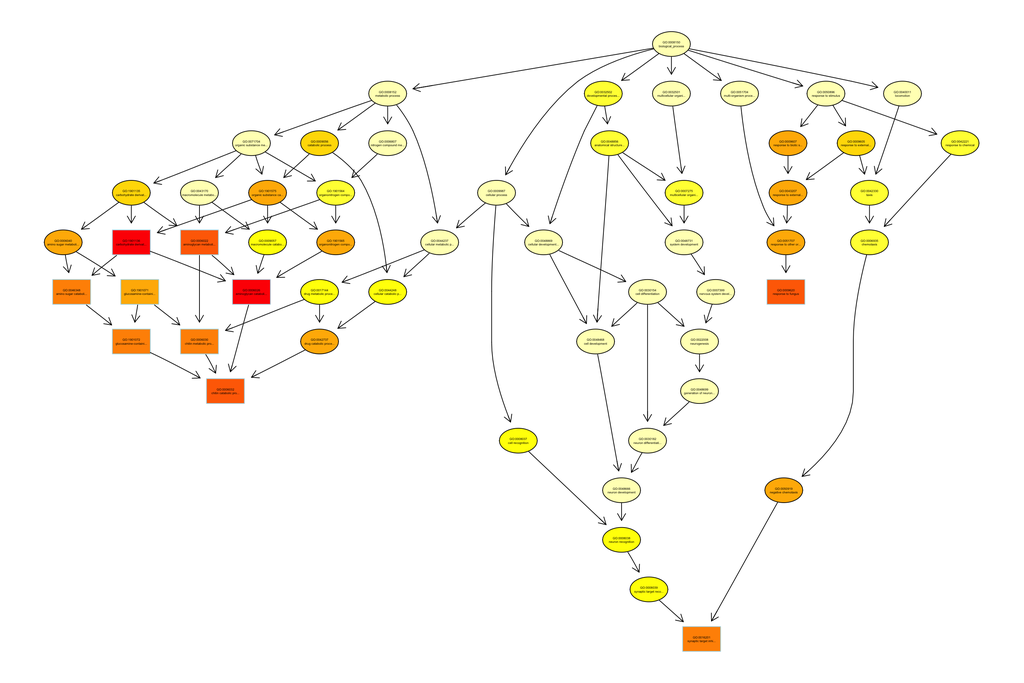

```
## $dag
## A graphNEL graph with directed edges
## Number of Nodes = 54
## Number of Edges = 87
##
## $complete.dag
## [1] "A graph with 54 nodes."
```

## Following limiting the functional annotation to just within the Insecta taxa level.

### Version

emapper version: emapper-2.0.1 emapper DB: 2.0

### Command

```bash
./emapper.py  -i obiroi.fa --cpu 30 -m diamond --tax_scope 50557 --target_taxa 7227 --data_dir dataDirConda/ --output eggnogAnno_CondaVersionPy2
```

### Annotation

The raw eggNog-mapper results can be found in the directory.

**eggNogMapper_AnnotationFromDrosophilaMelanogaster/eggNogMapper_Annotations/eggnogAnno_CondaVersionPy2_Scopeis50557_Targetis7227.emapper.annotations**

### Functional annotation graph correction

Following the GO annotation by eggNog-mapper we use topGO software to update assigned annotation accounting for the structured GO graph (i.e. A gene in a GO term must exist in one of the GO terms parent terms).

### Functional annotation graph enrichment testing

Functional annotation was performed by topGO and results separated in BP (Biological processes), MF (Molecular functions) and CC (cellular components) on the test set of proteins provided **“Proteins in secretion.xlsx”**.

Results tables are in

**eggNogMapper_AnnotationFromDrosophilaMelanogaster/topGO_Results/GO2Gene_eggnogAnno_CondaVersionPy2_Scopeis50557_Targetis7227_TopGO_BP.csv**

**eggNogMapper_AnnotationFromDrosophilaMelanogaster/topGO_Results/GO2Gene_eggnogAnno_CondaVersionPy2_Scopeis50557_Targetis7227_TopGO_MF.csv**

**eggNogMapper_AnnotationFromDrosophilaMelanogaster/topGO_Results/GO2Gene_eggnogAnno_CondaVersionPy2_Scopeis50557_Targetis7227_TopGO_CC.csv**

Results columns are –

- GO.ID - GO ID as provided by GO consortium.
- Term - Description of GO term.
- Annotated - Number of genes annotated to term.
- Significant - Number of genes annotated to term and within the test list of genes.
- Expected - Expected number of genes annotated to term and within the test list of genes.
- Rank in result2 - Rank of p-value if order by Result 2 column.
- result1 - pvalue of enrichment by hypergeometric test (Standard).
- result2 - pvalue of enrichment by hypergeometric test with elim algorithm GO graph correction (Ranks GO terms in bottom of GO graph higher i.e. most specific).
- result3 - pvalue of enrichment by hypergeometric test with weight algorithm GO graph correction (Ranks GO terms in middle of GO graph higher).
- GenesInTermAndTest - The genes annotated to term and within the test list of genes.
- GenesInTermAndTest_eggNogName - Any common names assigned by eggNog to genes annotated to term and within the test list of genes.

In addition we also run the GO enrichment using GOseq which will allow us to expand to other functional sets beyond GO.

Results are in

**eggNogMapper_AnnotationFromDrosophilaMelanogaster/GOseq_Results/GO2Gene_eggnogAnno__CondaVersionPy2_Scopeis50557_Targetis7227_GOSEQ.csv**

Results columns are –

- category - GO ID as provided by GO consortium.
- over_represented_pvalue - pvalue of enrichment by fisher test.
- under_represented_pvalue - pvalue of depletion by fisher test.
- numDEInCat - Number of genes annotated to term and within the test list of genes.
- numInCat - Number of genes annotated to term.
- term - Description of GO term.

## GO graph of Biological processes, top 10 enriched

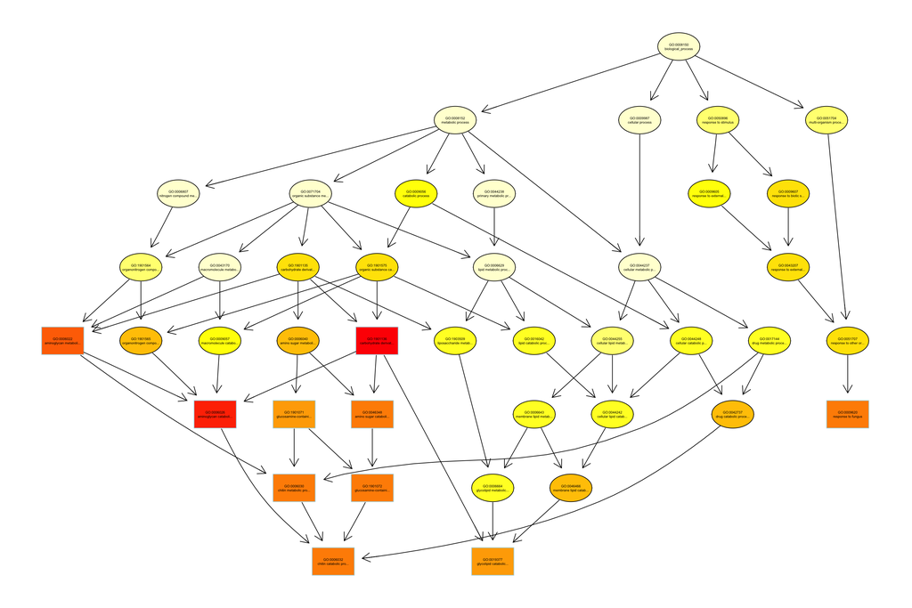

```
## $dag
## A graphNEL graph with directed edges
## Number of Nodes = 42
## Number of Edges = 73
##
## $complete.dag
## [1] "A graph with 42 nodes."
```